# Setting Both Policies

Manuel D. Rossetti, PhD P.E.

## Agenda

- Why neither location’s policy can be computed first
- A shortage cost for a hub that has none
- The two-level **iteration**, and what its stopping test does and does not mean
- Validating it against **exact** costs
- The cutout in **job lots**, where nothing exact reaches
- The same models on a worksheet, and in code
- What the chapter established

## A Circle

The **storeroom’s** policy needs the hub’s, through the wait.

The **hub’s** policy needs the storeroom’s, through the orders it passes up.

Neither can be computed first.

Under one-for-one ordering (chapter 9), the depot could be solved first, because its demand contained no storeroom policy. Batching breaks that.

## What Each Location Minimizes

Chapter 8’s cost, at each location:

$$C_i(r_i, Q_i) = \frac{k_i \lambda_i}{Q_i} + h\,\bar{I}_i(r_i, Q_i) + b_i\,\bar{B}_i(r_i, Q_i)$$

The storeroom’s $b_j$ is the shortage cost of its crews.

**The hub has no shortage cost of its own**, yet this formula needs one.

## A Target Becomes a Cost

Recall from chapter 4: a service constraint and a penalty are **the same thing seen from two sides**.

Set the hub’s $b_0$ from a fill rate target $\gamma_0$, through the critical ratio:

$$\frac{b_0}{b_0 + h} = \gamma_0 \quad\Longleftrightarrow\quad b_0 = \frac{\gamma_0\, h}{1 - \gamma_0}$$

With $\gamma_0 = 0.8$: $b_0 = 4h = \$2.2115$ per unit per week.

It is a **stated input**, and we will price it.

## Hold One Side, Solve the Other

The way out is the one chapter 4 took for a different coupling:

1. **Guess** the wait at the hub.
2. With the guess, the storeroom’s lead time is known: a chapter 8 location. **Solve it.**
3. With the storeroom’s policy, the hub’s demand is known: a chapter 8 location. **Solve it.**
4. The hub’s policy gives a wait. **It replaces the guess.**

Repeat until nothing moves.

## The Algorithm

```
twoLevel():
    E[W] <- 0,  Var[W] <- 0             // step 0: the hub never delays anyone
    loop:
        // step 1: the storeroom against the wait
        (r_j, Q_j) <- optimize, lead time demand over O_j + W
        // step 2: the hub against the storeroom's orders
        (r_0, Q_0) <- optimize, lead time demand by the recipe or the
                      convolution, b_0 from gamma_0
        // step 3: the wait the hub's policy implies
        E[W], Var[W] <- Little's law and its distributional form,
                        or the order's wait by the lead-time shift
        // step 4: stop when the four integers repeat
        if (r_j, Q_j, r_0, Q_0) == previous: return them
```

## Read Step 0

It is **the only guess** in the procedure.

A wait of zero says the hub always has stock.

That is the assumption a planner makes by default when modeling a location alone.

So the first pass **is the uncoupled planner’s answer**, and every pass after it is a correction.

## Read Step 4, Too

The test is that **the four integers stopped moving**.

Not that any optimality condition holds.

The iteration finds a **fixed point of a heuristic**: a pair of policies, each optimal given the other.

Nothing shows the pair is the best pair. A fixed point of a biased map is a biased answer that has stopped moving.

## Two Routes Through Each Step

**The moment route**

- the recipe at the hub, two moments at the storeroom
- works for **any** customers

**The exact route**

- the convolution, the order’s own wait, conditioning
- needs customers who take **one unit each**

## Both Policies for the Hub With Other Demand

The system of deck 2, but now **both batches are chosen**.

- Both locations pay $k = \$82.50$ an order
- The hub’s target is $\gamma_0 = 0.8$
- Two cutouts a week at the hub’s own customers and two at the storeroom
- $L_0 = 3$ weeks, $O_j = 1$ week

## The Trace, by the Moment Route

| Pass | Storeroom $(r_j, Q_j)$ | Storeroom cost | Hub $(r_0, Q_0)$ | Hub cost | $E[W]$, weeks | $\sigma_W$ |
| --- | --- | --- | --- | --- | --- | --- |
| 1 | $(-1, 26)$ | $13.09 | $(2, 47)$ | $20.99 | 0.5634 | 1.5988 |
| 2 | $(0, 29)$ | $14.35 | $(2, 48)$ | $21.71 | 0.6166 | 1.8033 |
| 3 | $(0, 29)$ | $14.65 | $(2, 48)$ | $21.71 | 0.6166 | 1.8033 |

**Pass 1** ignores the hub: with no wait, the storeroom holds a reorder point of $-1$ against a week of transit.

The hub’s answer implies a wait of 0.56 weeks, standard deviation 1.6.

**Pass 2** raises the storeroom’s reorder point by one and its batch by three. **Pass 3** changes nothing.

## Notice the Pass 3 Cost

The storeroom’s **policy** is the same at passes 2 and 3.

Its **cost** is not: $14.35, then $14.65.

Each pass prices the storeroom against the wait **the pass before it left**. Pass 2 pays against 0.56 weeks; pass 3 against 0.62.

## The Exact Route

Also three passes. It reaches hub $(2, 48)$ and storeroom **$(3, 28)$**.

Its storeroom holds **three more units**. Why?

Its orders of 28 wait for their **last unit**: 1.75 weeks on average.

The moment route carries a **customer’s** wait, 0.62 weeks.

Priced exactly: the moment route’s answer costs **$34.35 a week**, the exact route’s **$33.54**.

## Validating the Iteration

An iteration never checked against an exact answer is one you are asked to **trust**.

We do not have to ask.

In Axsäter’s setting there is an exact cost. With one-unit customers the chapter’s own route gives one **everywhere**.

## Four Checks

| System | Fixed point, exactly | Exact optimum | Gap |
| --- | --- | --- | --- |
| Part I, batches held: hub $(11, 8)$, $S_j = 3$ | $7.4337 | $7.0195 at $(9, 3)$ | 5.9% |
| One batching storeroom, hub at one batch | $3.5354 | $3.4111 | 3.6% |
| Part II, both batches chosen, exact route | $33.5370 | $33.3955 nearby | 0.4% |
| Part II, both batches chosen, moment route | $34.3462 | $33.3955 nearby | 2.9% |

In **every** case the fixed point holds more at the hub than the exact optimum does.

## Read the Gaps in Domain Terms

The exact optima run the hub at a **low ready rate**: 0.60 in Part I.

A unit at the hub protects every storeroom **a little**.

A unit at a storeroom protects its own crews **a lot**.

A hub target of 0.8 already asks for more protection than the system wants.

**The target is the input to choose with care; the route matters less.** Repeat this comparison on your own items whenever an exact cost is available.

## The Cutout in Job Lots

Chapter 8’s cutout is drawn in **job lots**. Nothing exact in Parts I and II reaches it.

A lot can carry the position past the reorder point, and the undershoot varies.

The **moment route** needs only two moments at each location.

Those are available.

## The Setting

Crews draw cutouts in lots of 1, 2 or 4 with probabilities 0.40, 0.40, 0.20 (chapter 8’s lots).

- Lots reach the storeroom at **150 a year**; the hub serves **250 lots a year** of its own
- Supplier: two months. Transfer to the storeroom: one month.
- $82.50 an order, $28.75 a unit a year to hold, $287.50 a unit a year owed
- $\gamma_0 = 0.8$, so $b_0 = \$115$ a year. **This example works in years.**

*Demand?* Compound Poisson at both locations. *Review?* Continuous. *Replenishment?* Each location’s position reaching its reorder point, for its batch. *Unmet demand?* Backordered.

## The Moments

$$E[Y] = 0.4(1) + 0.4(2) + 0.2(4) = 2.0, \qquad E[Y^{2}] = 0.4 + 1.6 + 3.2 = 5.2$$

So 300 units a year at the storeroom and 500 of the hub’s own.

A lot is at most 4 and the storeroom’s batch will be near 50, so **every storeroom order is exactly $Q_j$**.

The hub, by the recipe with compound Poisson customers, at $Q_j = 49$:

$$\text{mean} = 800 \times \tfrac{2}{12} = 133.33, \qquad
\text{variance} = (250 + 150)\tfrac{2}{12}(5.2) + \tfrac{49^{2}}{6} = 346.67 + 400.17 = 746.83$$

## The Trace

| Pass | Storeroom $(r_j, Q_j)$ | Hub $(r_0, Q_0)$ |
| --- | --- | --- |
| 1 | $(22, 48)$ | $(120, 92)$ |
| 2 | $(25, 49)$ | $(120, 92)$ |
| 3 | $(25, 49)$ | $(120, 92)$ |

- Storeroom: **$1,371.26** a year; hub: **$2,279.69** a year
- The hub’s orders wait 0.0054 years on average: **about two days**

## What It Says

The coupling moves the storeroom’s reorder point by **three units**, from the planner who ignores the hub to the converged answer.

The hub’s policy **does not move at all**: the storeroom’s batch barely changes, and the hub’s lead time demand barely changes with it.

The storeroom’s batch contributes **400 of the 747** units squared of the hub’s variance: more than all the customers together. A hub serving a storeroom that orders fifty at a time faces a demand **its customers never place**.

## And Its Limit

Nothing exact covers this case.

The assumption that breaks is stated: **customers who take one unit each**.

What remains is to check the answer **by simulation**, which chapter 11 builds.

## The Models on a Worksheet

`Chapter10Models.xlsx`, one sheet per section, no macros:

- **Part I:** `Hub`, `Delay` (a row a day), `Exact` (Axsäter’s recursion down a grid), `Storeroom` (the three routes)
- **Part II:** `Orders`, `HubGeneral` (exact, recipe, shortcut), `OrderDelay`, `RandomLead`
- **Part III:** `Iterate`: the iteration **by hand**

A sheet cannot run chapter 8’s search by itself. You type each pass’s policies; the sheet prices them and their four neighbours and hands the wait to the next pass.

## The `Iterate` Sheet

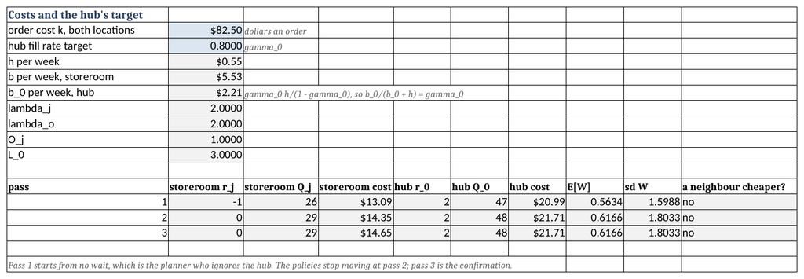

## Reading It

The last column reads **“no”** on every pass: no neighbour of any typed policy is cheaper.

Passes 2 and 3 **agree**: the stopping test of the algorithm, read off a sheet.

## What a Larger Hub Batch Does

The utility is offered a price break for ordering cutouts **twelve at a time** instead of eight.

Before weighing the price: what does the larger batch do to the **system**, with everything else held?

*Step 1.* On `Hub`, $r_0 = 9$, $Q_0 = 8$. `Exact!B28` reads **$7.0195** a week.

*Step 2.* Type **12** into `Hub!B19`, and read down the sheets.

## Two Cells Typed

| Cell | What it is | $Q_0 = 8$ | $Q_0 = 12$ |
| --- | --- | --- | --- |
| `Hub!B22` | $\bar{B}_0$ | 1.0273 | 0.6984 |
| `Hub!B23` | $\overline{\mathit{RR}}_0$ | 0.6030 | 0.7242 |
| `Hub!B27` | $\bar{W}$, weeks | 0.2568 | 0.1746 |
| `Storeroom!E19` | backorders per storeroom | 0.0726 | 0.0567 |
| `Exact!B28` | system cost per week | $7.0195 | $7.7367 |

The hub holds more, so it owes less, and the crews wait less.

And the system costs **$0.72 a week more**. The cheapest $S_j$ is still 3.

## Now Move the Reorder Point

Holding more at the hub is more protection than the system wants, so **lower `Hub!B18`**.

At 7, `Exact!B28` reads **$7.5379**: the cheapest reorder point for a batch of twelve.

*The check.* On `Storeroom`, exact and conditioned backorders at $Q_0 = 12$ are 0.0567 and 0.0568, apart only by the day grid. ✓

## Is the Price Break Worth It?

Without an ordering cost the larger batch cannot pay for itself: it only adds stock.

Its best version costs **$0.52 a week** more than the present policy: **$27 a year**.

The hub buys about 208 cutouts a year. A **thirteen-cent** discount pays for it.

A planner who changed the batch **and left the reorder point** would have priced the offer at $0.72 a week instead of $0.52.

## The Same Models in Code

`inventory.multiechelon`, one class per idea:

- `BatchedHub`: the convolution, the recipe, the shortcut, the hub’s measures
- `HubDelay`: a customer’s wait, or an order’s
- `StoreroomWithDelay`: the three routes
- `AxsaterBatchOrdering`: the exact yardstick
- `TwoLevelIteration`: the algorithm, and the exact price of any policy

```kotlin
for ((hr, sr) in listOf(HubRoute.MOMENTS to StoreRoute.MOMENTS,
                        HubRoute.EXACT to StoreRoute.CONDITIONED)) {
    val result = TwoLevelIteration(problem, hr, sr).solve()
    println(TwoLevelIteration.exactSystemCost(problem, result.policy, b))
}
```

## What It Prints

```
### Part III: the two-level iteration
  moments route, 3 passes:
    1  hub (2, 47), storeroom (-1, 26)  E[W] 0.5634
    2  hub (2, 48), storeroom (0, 29)  E[W] 0.6166
    3  hub (2, 48), storeroom (0, 29)  E[W] 0.6166
    priced exactly: 34.3462 a week
  exact route, 3 passes:
    1  hub (2, 48), storeroom (-1, 26)  E[W] 1.6250
    2  hub (2, 48), storeroom (3, 28)  E[W] 1.7500
    3  hub (2, 48), storeroom (3, 28)  E[W] 1.7500
    priced exactly: 33.5370 a week
```

Every number the chapter prints has a test behind it.

## What the Chapter Established (1)

**A storeroom that batches passes up its customers’ demand in whole batches.** Lumpier, and more regular. Countable from the Poisson table.

**One move carries the chapter: condition on the position, then average.** Chapter 8’s $(r, Q)$ measures, Axsäter’s equation (1), the order-count law, a random lead time.

**With one-for-one storerooms, everything is exact.** The wait’s distribution is the ready rate at a shorter lead time.

## What the Chapter Established (2)

**Conditioning a storeroom on the wait is exact**, and for a batching storeroom the wait is **its order’s own**.

**Little’s law gets the mean right, and the mean is not enough.** 30% low on the running example.

**The recipe is sound; the shortcut over-stocks.**

**A random lead time: build at each value, then average.**

**The iteration converges fast, and its answer depends most on the hub’s target.**

## Where We Are

- The two policies come from a **fixed point**, each optimal given the other
- The hub’s shortage cost comes from a **target**, and the target matters most
- Checked exactly, the fixed points land within **0.4% to 5.9%** of the optimum
- Job lots are handled by moments, and **simulation** is what checks them

Next: chapter 11, where a system’s behavior is **generated** rather than solved for.

⌂ Index